# K-Means Demo

December 25, 2019

## Summary

Clustering is one of the most data exploratory analysis used to get a insights from data. It helps to identify subgroups that can help us to identify how the data is structured.

Kmeans is an algorithm that tries to split the dataset into K pre-defined distinct groups (non-overlaping), which are called clusters.

Using the application we can create a random dataset and then running the k-means algorithm to see how the data is clusterized. We can visualize the plot to learn how the different clusters, its centroids and its points are created.

## Configuration Panel

To build the plot, we have the folowing options:

- Slider for Number of Points: to define how many points will be generated randomly.
- Button to generate random data: to generate 20 random points.
- Slider for Number of Clusters: to define how many clusters to show.
- Checkbox for configuration: to enable/disable centroids and areas.
- Button to build clusters: to build the clusters with k-mean algorithm.

## Random DataSet

We can create a random dataset with 20 (default) or more points by pressing the **Generate Random Points** button. It will execute the next code:

```r
qtyPoints <- input$slidePoints;
dfData <- data.frame( x = runif(qtyPoints, min = 0, max = 100),
                    y = runif(qtyPoints, min = 0, max = 100));
```

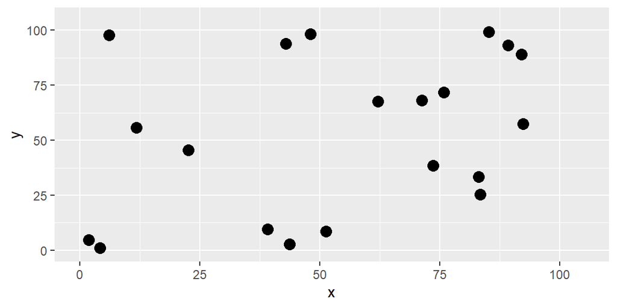

## Making Clusters

By pressing **Make Clusters** button, it will execute the kmeans algorithm on the data and then will plot the clusters (according configuration).

```r
objCluster <- kmeans(dfData, centers = input$slideClusters);
```

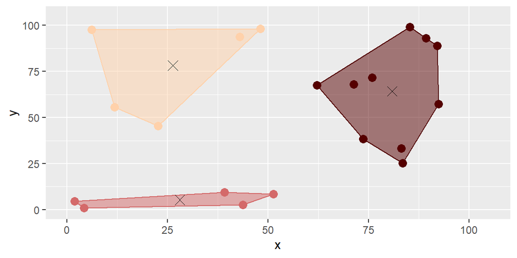